# An excess of Cronbach’s α values at rule-of-thumb cut-offs

Analyses of I/O dataset

Ian Hussey

26 July, 2024

# Dependencies

```r
library(tidyverse)
library(scales)
library(ggtext)
library(broom)
library(extraDistr)
library(patchwork)
library(coin)
library(knitr)
library(kableExtra)

dir.create("plots")

# disable scientific notation
options(scipen=999)

# set seed
set.seed(42)
```

# Get data

```r
data_processed <- read_rds("../../data/processed/IO/data_processed_io.rds") |>
  # round the alpha values to 2 decimal places, using standard rounding method
  # recode alpha values of 0 or 1 to .01 or .99, in order to be able to fit beta regression
  # nb none present in dataset
  mutate(alpha = janitor::round_half_up(alpha, 2),
         alpha = case_when(alpha == 0 ~ 0.01,
                           alpha == 1 ~ 0.99,
                           TRUE ~ alpha))
```

# Descriptives

```r
data_metabus <- read_rds("../../data/processed/IO/data_processed_io.rds")

n_doi <- nrow(data_metabus)

cat("n articles =",
      n_doi, "\n")
```

```
## n articles = 89644
```

```r
n_estimates_after_exclusions <- data_processed |>
  count(name = "n_estimates") |>
  pull(n_estimates)

cat("n alpha estimates after exclusions =",
      n_estimates_after_exclusions, "\n")
```

```
## n alpha estimates after exclusions = 89644
```

# Kernel smoothing

## Model and plot

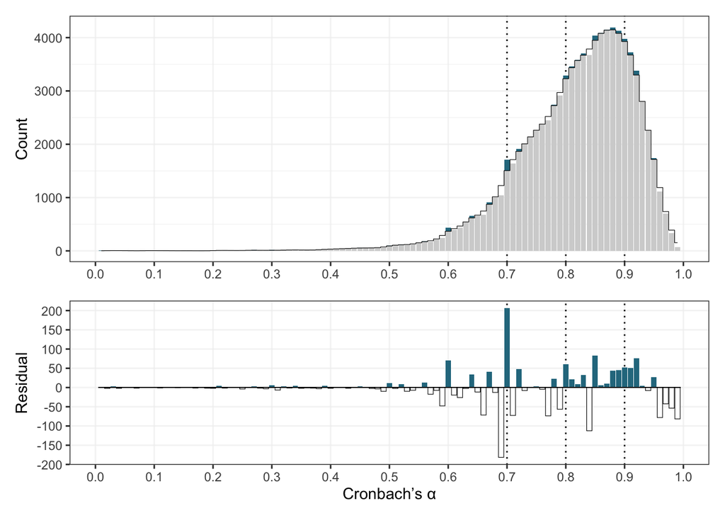

```r
# create tibble containing all alpha bins, for a later join
all_alphas <- tibble(alpha = as.character(seq(0.01, 0.99, 0.01)),
                     freq = 0,
                     missing = TRUE)

data_frequency_temp <- data_processed %>%
  mutate(n_total = n()) %>%
  group_by(alpha) %>%
  summarise(freq = sum(!is.na(alpha))/first(n_total)) %>%
  # convert alpha to character to facilitate a join later
  mutate(alpha = as.character(alpha))

# kernel density estimation
data_density <-
  density(data_processed %>%
            pull(alpha),
          n      = length(seq(0.01, 0.99, 0.01)),
          from   = 0.01,
          to     = 0.99,
          kernel = "gaussian",
          bw     = 0.01) # "nrd0" in the psychology dataset returns 0.01

data_frequency <-
  # join the previous two tibbles to create a complete list of alpha bins
  data_frequency_temp %>%
  bind_rows(all_alphas %>% anti_join(data_frequency_temp, by = "alpha")) %>%
  arrange(alpha, desc(freq)) %>%
  distinct(alpha, .keep_all = TRUE) %>%
  mutate(density_kernel = data_density$y,
         missing = ifelse(is.na(missing), FALSE, missing)) %>%
  mutate(residual_kernel = freq*100 - density_kernel,
         alpha = as.numeric(alpha),
         missing = ifelse(is.na(missing), FALSE, missing))

data_diff <- data_frequency %>%
  mutate(frequency = freq*100,
         frequency_without_residual_kernel = if_else(residual_kernel > 0, frequency - residual_kernel, frequency),
         pos_resid_kernel = residual_kernel > 0,
         residual_kernel = if_else(residual_kernel > 0, residual_kernel, -1 * residual_kernel)) %>%
  dplyr::select(alpha,
                #fitted,
                density_kernel,
                pos_resid_kernel,
                frequency_without_residual_kernel,
                residual_kernel) %>%
  pivot_longer(names_to = "type",
               values_to = "residual_kernel",
               c(frequency_without_residual_kernel, residual_kernel))

total_n <- nrow(data_processed)/100

plot_data_io <- data_processed |>
  mutate(n_total = n()) |>
  group_by(alpha) |>
  summarise(count = sum(!is.na(alpha))) |>
  mutate(type = case_when(alpha %in% c(.70, .80, .90) ~ "Common reliability threshold",
                          TRUE ~ "Non-threshold"),
         type = fct_relevel(type, "Non-threshold", "Common reliability threshold")) |>
  right_join(data_frequency, by = "alpha") |>
  mutate(excess = if_else(residual_kernel > 0, "excess", "deficit")) %>%
  drop_na()

c_excess <- "#2A788EFF"
c_data <- "lightgrey"
c_line <- "black"
c_lpbg <- "white"
c_grid <- "#F0F0F0AA"

p1_kernel_io <-
  ggplot(plot_data_io, aes(alpha, y = count, fill = excess)) +
  geom_vline(xintercept = c(0.7, 0.8, 0.9), linetype = "dotted") +
  geom_col() +
  geom_col(aes(y = count - if_else(residual_kernel > 0, residual_kernel * total_n, 0)), fill = c_data) +
  geom_step(aes(y = density_kernel * total_n, group = 1), direction = "mid", size = 0.2, color = c_line) +
  scale_fill_manual(values = c(c_data, c_excess),
                    name = element_blank()) +
  scale_x_continuous(breaks = seq(from = 0, to = 1, by = 0.1),
                     labels = label_number(accuracy = 0.1),
                     minor_breaks = NULL) +
  theme_bw() +
  labs(x = "",
       y = "Count") +
  theme(axis.title.x = element_markdown()) +
  ylim(0, 4200) +
  theme(legend.position = "none",
        legend.background = element_blank(),
        panel.grid = element_line(color = c_grid))

p2_kernel_io <-
  ggplot(plot_data_io, aes(alpha, residual_kernel * total_n, fill = excess)) +
  geom_vline(xintercept = c(0.7, 0.8, 0.9), linetype = "dotted") +
  geom_col(aes(color = excess), size = 0.2) +
  scale_color_manual(values = c(c_line, "#FFFFFF00")) +
  geom_segment(x = 0.005, xend = 0.995, y = 0,yend=0, size = 0.2, color = c_line) +
  scale_fill_manual(values = c("white", c_excess),
                    guide = guide_legend(reverse = TRUE)) +
  scale_x_continuous(breaks = seq(from = 0, to = 1, by = 0.1),
                     labels = label_number(accuracy = 0.1),
                     minor_breaks = NULL) +
  scale_y_continuous(breaks = seq(from = -200, to = 200, by = 50),
                     labels = label_number(accuracy = 1),
                     minor_breaks = NULL) +
  theme_bw() +
  labs(x = "Cronbach's &alpha;",
       y = "Residual") +
  theme(legend.title = element_blank(),
        axis.title.x = element_markdown(),
        legend.position = "none",
        panel.background = element_rect(fill = c_lpbg),
        panel.grid = element_line(color = c_grid)) # c(0.23, 0.77), legend.background = element_blank()

p_kernel_io <-
  p1_kernel_io +
  p2_kernel_io +
  plot_layout(nrow = 2, heights = c(1.5, 1))

p_kernel_io
```

```r
write_rds(p_kernel_io, "plots/p_kernel_io.rds")

ggsave("plots/p_kernel_io.pdf",
       plot = p_kernel_io,
       dev = cairo_pdf,
       width = 6,
       height = 4.5,
       units = "in")

ggsave("plots/p_kernel_io.png",
       plot = p_kernel_io,
       dev = png,
       width = 6,
       height = 4.5,
       dpi = 600,
       units = "in")
```

## Quantify excess

```r
data_inflation_kernel <- data_frequency %>%
  filter(missing == FALSE) %>%
  dplyr::select(alpha,
                observed = freq,
                predicted = density_kernel,
                residual = residual_kernel) %>%
  mutate(predicted = predicted/100,
         residual = residual/100,
         inflation = (observed/predicted - 1),
         inflation_for_reporting = janitor::round_half_up(inflation*100, digits = 0),
         group_3_cutoffs = as.factor(case_when(alpha %in% c(.70, .80, .90) ~ "cutoff",
                                               TRUE ~ "non cutoff")),
         group_1_cutoff = as.factor(case_when(alpha %in% c(.70) ~ "cutoff",
                                               TRUE ~ "non cutoff")))

write_csv(data_inflation_kernel, "plots/residuals_io.csv")
```

- There were 14% more observations of Cronbach’s $\alpha$ = .70 than predicted.
- There were 2% more observations of Cronbach’s $\alpha$ = .80 than predicted.
- There were 1% more observations of Cronbach’s $\alpha$ = .90 than predicted.

## Permutation tests

.70, .80, and .90 against the rest:

```r
independence_test(residual ~ group_3_cutoffs,
                  data = data_inflation_kernel,
                  distribution = "exact",
                  alternative = "greater")
```

```
##
##  Exact General Independence Test
##
## data:  residual by group_3_cutoffs (cutoff, non cutoff)
## Z = 4.529, p-value = 0.0001594
## alternative hypothesis: greater
```

.70 against the rest:

```r
independence_test(residual ~ group_1_cutoff,
                  data = data_inflation_kernel,
                  distribution = "exact",
                  alternative = "greater")
```

[output not shown]

# Caliper tests

See Gerber et al. (2010) “Publication Bias in Two Political Behavior Literatures”

Using alpha ± 0.01 calipers.

The usual null hypothesis of no differences cannot be tested against, so instead I calculate over/under ratios for each 0.01 and its neighbor, i.e., ratio = count($\alpha_x$) / count($\alpha_{x-0.01}$). Because very few counts are present in < .50, which makes the ratios very poorly estimated, I exclude these values. The hypothesis that the ratio for the cut-off score ratio being larger than the ratios calculated from non cut-offs is then tested via permuation test.

## Quantify excess

```r
data_caliper <- data_processed %>%
  mutate(n_total = n()) %>%
  group_by(alpha) %>%
  summarise(count = sum(!is.na(alpha)))

data_caliper |>
  filter(alpha %in% c(.69, .70, .79, .80, .89, .90)) |>
  mutate(type = ifelse(alpha %in% c(.70, .80, .90), "threshold", "nonthreshold"),
         cutoff = case_when(alpha %in% c(.69, .70) ~ .70,
                            alpha %in% c(.79, .80) ~ .80,
                            alpha %in% c(.89, .90) ~ .90)) |>
  select(-alpha) |>
  pivot_wider(names_from = type,
              values_from = count) |>
  mutate(ratio = janitor::round_half_up(threshold/nonthreshold, 2)) |>
  kable() |>
  kable_classic(full_width = FALSE)
```

| cutoff | nonthreshold | threshold | ratio |
| --- | --- | --- | --- |
| 0.7 | 1044 | 1712 | 1.64 |
| 0.8 | 2914 | 3290 | 1.13 |
| 0.9 | 4126 | 3979 | 0.96 |

```r
data_caliper_all <- data_caliper |>
  mutate(ratio = count/lag(count),
         group_3_cutoffs = as.factor(case_when(alpha %in% c(.70, .80, .90) ~ "cutoff",
                                               TRUE ~ "non cutoff")),
         group_1_cutoff = as.factor(case_when(alpha %in% c(.70) ~ "cutoff",
                                              TRUE ~ "non cutoff")))
```

## Plot

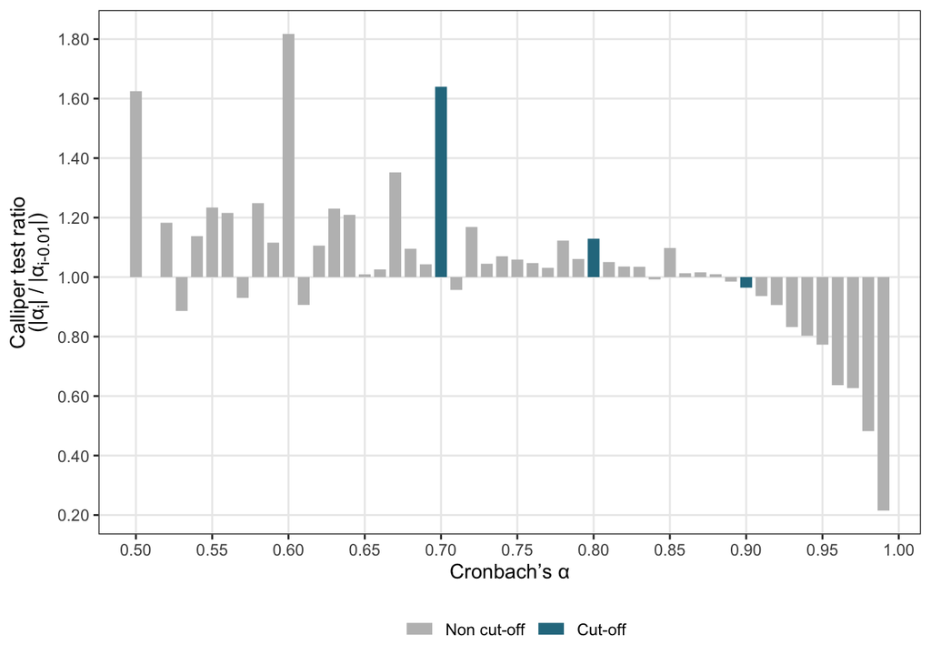

```r
cbp2 <- c("grey", "#2A788EFF")

p_caliper_all_io <-
  data_caliper_all |>
  filter(alpha >= .50) |>
  mutate(type = case_when(alpha %in% c(.70, .80, .90) ~ "Cut-off",
                          TRUE ~ "Non cut-off"),
         type = fct_relevel(type, "Non cut-off", "Cut-off")) |>
  #mutate(type = ifelse(ratio > 1, "1", "2")) |>
  ggplot(aes(x = alpha, y = ratio, fill = type, color = type)) +
  #geom_vline(xintercept = c(0.7, 0.8, 0.9), linetype = "dotted") +
  #geom_col(position = "stack") +
  geom_segment(aes(x = alpha,
                   xend = alpha,
                   y = 1,
                   yend = ratio), size = 3) +
  #scale_color_viridis_d(direction = -1, begin = 0.2, end = 0.6, option = "plasma") +
  #scale_color_viridis_d(direction = -1, begin = 0.2, end = 0.55, option = "magma") +
  scale_color_manual(values = cbp2) +
  scale_x_continuous(breaks = seq(from = 0, to = 1, by = 0.05),
                     labels = label_number(accuracy = 0.01),
                     minor_breaks = NULL) +
  scale_y_continuous(breaks = seq(from = 0, to = 2, by = 0.2),
                     labels = label_number(accuracy = 0.01),
                     minor_breaks = NULL) +
  theme_bw() +
  labs(x = "Cronbach's &alpha;",
       #y = "Ratio<br />n(&alpha;<sub>i</sub>) / n(&alpha;<sub>i-0.01</sub>)",
       y = "Calliper test ratio<br />(|&alpha;<sub>i</sub>| / |&alpha;<sub>i-0.01</sub>|)",
       color = "") +
  theme(legend.position = "bottom",
        axis.title.x = element_markdown(),
        axis.title.y = element_markdown())

p_caliper_all_io
```

```r
write_rds(p_caliper_all_io, "plots/p_caliper_all_io.rds")

ggsave("plots/p_caliper_all_io.pdf",
       plot = p_caliper_all_io,
       device = cairo_pdf,
       width = 6,
       height = 4,
       units = "in")
```

Note that $|\alpha_i|$ refers to cardinality (i.e., count) rather than absolute value. Unfortunately these are annotated in the same way using vertical bars.

Note excesses at .50 and .60 as well as .70.

## Permutation tests

.70/.69, .80/.79, and .90/.89 against the rest:

```r
independence_test(ratio ~ group_3_cutoffs,
                  data = filter(data_caliper_all, alpha >= .50),
                  distribution = "exact",
                  alternative = "greater")
```

```
##
##  Exact General Independence Test
##
## data:  ratio by group_3_cutoffs (cutoff, non cutoff)
## Z = 1.4005, p-value = 0.09214
## alternative hypothesis: greater
```

.70/.69 against the rest:

```r
independence_test(ratio ~ group_1_cutoff,
                  data = filter(data_caliper_all, alpha >= .50),
                  distribution = "exact",
                  alternative = "greater")
```

```
##
##  Exact General Independence Test
##
## data:  ratio by group_1_cutoff (cutoff, non cutoff)
## Z = 2.3401, p-value = 0.04
## alternative hypothesis: greater
```